# Who Leads and What Follows: The Economic Impact of Political Systems and Female Leadership

- Show All Code
- Hide All Code
- View Source

Author

Addie Weaver, Scarlet Kwan, Sophia Woodard

## Introduction

Political systems and their leaders shape the way countries are governed. Overtime, countries have had many leadership & regime changes that have influenced the economic outcomes of their country. In hopes to explore that influence, we attempted to collect accurate & exhaustive data on many countries over time to analyze.

## The Data Behind the Analysis

Our exhaustive data collection comes from a combination of three open source datasets.

### Tracking Regimes and Leadership

Our first data set was created by two economics researchers who were studying different governments and how they change over time. The purpose of this dataset was to be a resource for those interested in studying how different countries and political systems transition through the years. Additionally, the two researchers, Christian Bjørnskov and Martin Rode, when doing their own research, felt that the data available at the time was inadequate.

The dataset includes information on 192 different sovereign countries and 16 other self-governed territories from the years 1950 to 2020 on each of these countries’ regime type, democratic status, leadership, elections, transfers of power, and their colonial history.

This dataset was an expansion on other collections of geopolitical data that the authors took and added more information to. The information included features of government, elections, leadership types, and more. When it came to our analysis for this data, it was incredibly helpful to have all this information because it gave us the ability to have an accurate list of all the sovereign countries and classify them into different categories based on regime, leader, and more. Additionally, it provided us with additional information that gave context to each of these countries.

https://www.christianbjoernskov.com/bjoernskovrodedata/

### Measuring Economic Performance

Our second dataset comes from API Ninjas and is an API with GDP data on all 192 sovereign countries. This data provided us with a wide range of GDP-related variables and information for each country. Some examples of this include GDP per country, GDP per country per capita, nominal GDP, and more. The observational unit was each country and year combination, the API provides current and historical GDP data for countries around the world. API Ninjas didn’t explicitly state where they got their data from, so we don’t have full transparency on where the data came from, nor why they collected it.

These data are of interest as GDP is one of the most used and recognized measures of national economic output. By linking GDP figures to the Regime and Leadership data, we are able to track how the economies of countries over time with many different regimes and leadership types. For our research purposes, we focused on GDP per country in billions of United States dollars. Additionally, when extracting this data from the API to merge it with our geopolitical data, we used both the country name and code.

https://api-ninjas.com/api/gdp

### Tracking Employment and Economic Stability

Our third dataset is from API Ninjas and is an API with unemployment data. This API provides data on the historical, current, and projected future unemployment statistics about every country in the world. This data can be retrieved through programming and can be queried by country name or ISO country code. The response variables in the data includes the country, the year of observation, and the unemployment rate in percentage form. The observational unit was each country and year combination. API Ninjas didn’t explicitly state where they got their data from, so we don’t have full transparency on where the data came from. The data was collected over multiple years and over a lot of countries to get the most in depth and detailed and informative data possible.

A country’s unemployment rate is important because it shows how healthy its economy is, with low unemployment usually meaning people are working, earning money, and spending, which helps the economy grow, and high unemployment suggesting economic problems, with fewer jobs available and lower incomes. Different organizations like governments and businesses use this information on unemployment to make decisions about policies, hiring, and investments. By combining this data with our leadership and regime data, we are able to answer questions regarding the relationship between a country’s unemployment rate and their government or socio-economic characteristics, in this case whether the regime of the country affects the unemployment rate.

https://api-ninjas.com/api/unemployment

## What We Set Out to Discover

We have two research questions we were interested in learning more about, How has Gross Domestic Project (GDP) changed for top countries with most female leaders over time? , as well as, Does the type of regime of a country/region affect the unemployment rate?

## How has Gross Domestic Project (GDP) changed for top countries with most female leaders over time?

We first wanted to investigate the countries with the highest number of years of female national leadership along with their average GDP. To do this, we made a table to find the top 10 countries with the highest years of female leaders and average the GDP for those countries over time.

```r
top_10_female_leaders_gdp <- democracy_gdp |>
  filter(!is.na(gdp)) |>
  group_by(country_name, country_code) |>
  summarize(
    years_with_female_leader = sum(female_leader, na.rm = TRUE),
    avg_gdp = mean(gdp),
    .groups = "drop"
  ) |>
  slice_max(years_with_female_leader, n = 10, with_ties = FALSE)

#Table of Top Female Leaders with their GDP
top_10_female_leaders_gdp|>
gt(caption =  "Table 1. Countries with the Most Years of Female National Leadership") |>
  tab_header(
    title = md("**Countries with the Most Years of Female National Leadership**"),
    subtitle = "Based on country-years with available GDP data"
  ) |>
  cols_label(
  country_name = "Country",
    country_code = "Country Code",
    years_with_female_leader = "Years with Female Leader",
    avg_gdp = "Average GDP") |>
  fmt_currency(avg_gdp, currency = "USD", decimals = 0) |>
  tab_style(
    style = cell_text(weight = "bold"),
    locations = cells_column_labels()
    )
```

Table 1. Countries with the Most Years of Female National Leadership

**Countries with the Most Years of Female National Leadership**

Based on country-years with available GDP data

| Country | Country Code | Years with Female Leader | Average GDP |
| --- | --- | --- | --- |
| Denmark | DNK | 41 | $211 |
| United Kingdom | GBR | 41 | $1,814 |
| Netherlands | NLD | 33 | $541 |
| Ireland | IRL | 21 | $153 |
| Aruba | ABW | 18 | $2 |
| Hong Kong | HKG | 18 | $170 |
| Iceland | ISL | 16 | $11 |
| Liberia | LBR | 15 | $2 |
| Philippines | PHL | 15 | $137 |
| Chile | CHL | 12 | $120 |

We can see in our table that Denmark and the United Kingdom have the greatest number of years (41), followed by the Netherlands and Ireland, while other countries have fewer years of female leadership. The average GDP values vary widely across these countries, ranging from very low values like for Aruba and Liberia, to much higher values like for the United Kingdom), indicating substantial differences in economic size among them.

After that, we decided to explore the percent change of GDP from each of those countries in the previous table. We found the first and last year of data from each of the countries, and calculated the percent change. In our table, you can see each of the first and last year, the gdp at those years, the change in dollars and the change as a percent.

```r
summarize_country_gdp_change <- function(country) {
  democracy_gdp |>
    filter(country_name == country, !is.na(gdp)) |>
    arrange(year) |>
    summarize(
      country_name = first(country_name),
      first_year = first(year),
      last_year = last(year),
      first_gdp = first(gdp),
      last_gdp = last(gdp),
      gdp_change = last_gdp - first_gdp,
      percent_change = gdp_change / first_gdp
    )
}

gdp_change_table <- top_10_female_leaders_gdp$country_name |>
  map_dfr(summarize_country_gdp_change)

gdp_change_table |>
  gt(caption = "Table 2. GDP Change Over Time for Countries with the Most Female Leadership") |>
  tab_header(
    title = md("**GDP Change Over Time for Countries with the Most Female Leadership**"),
    subtitle = "First and last years of available GDP data by country"
  ) |>
  cols_label(
    country_name = "Country",
    first_year = "First Year",
    last_year = "Last Year",
    first_gdp = "First GDP",
    last_gdp = "Last GDP",
    gdp_change = "GDP Change",
    percent_change = "Percent Change"
  ) |>
  fmt_currency(
    columns = c(first_gdp, last_gdp, gdp_change),
    currency = "USD",
    decimals = 0
  ) |>
  fmt_percent(percent_change, decimals = 1) |>
  tab_style(
    style = cell_text(weight = "bold"),
    locations = cells_column_labels()
  ) |>
  tab_style(
    style = cell_fill(color = "#76B7B2"),
    locations = cells_body(columns = percent_change)
  )
```

Table 2. GDP Change Over Time for Countries with the Most Female Leadership

**GDP Change Over Time for Countries with the Most Female Leadership**

First and last years of available GDP data by country

| Country | First Year | Last Year | First GDP | Last GDP | GDP Change | Percent Change |
| --- | --- | --- | --- | --- | --- | --- |
| Denmark | 1980 | 2020 | $71 | $356 | $285 | 402.2% |
| United Kingdom | 1980 | 2020 | $605 | $2,699 | $2,094 | 346.3% |
| Netherlands | 1980 | 2020 | $194 | $932 | $738 | 380.2% |
| Ireland | 1980 | 2020 | $21 | $436 | $415 | 1,936.0% |
| Aruba | 1995 | 2020 | $1 | $3 | $1 | 93.7% |
| Hong Kong | 1980 | 2020 | $29 | $345 | $316 | 1,095.1% |
| Iceland | 1980 | 2020 | $3 | $22 | $18 | 529.9% |
| Liberia | 2000 | 2020 | $1 | $3 | $2 | 251.9% |
| Philippines | 1980 | 2020 | $37 | $362 | $325 | 875.5% |
| Chile | 1980 | 2020 | $29 | $254 | $225 | 775.1% |

We found that all countries show an increase in GDP, though the magnitude of growth varies widely across countries. Some countries, such as Ireland and Hong Kong, have very large percent increases, while others like Aruba and Liberia show more modest growth over their observed time periods.

After making our tables, we wanted to see this data visually to see trends a bit more clearly. We started with the average GDP from top countries with female leaders, reflecting the data from table 1. Using a line plot, we wanted to investigate the relationship between the number of years of female national leadership and average GDP for the selected countries.

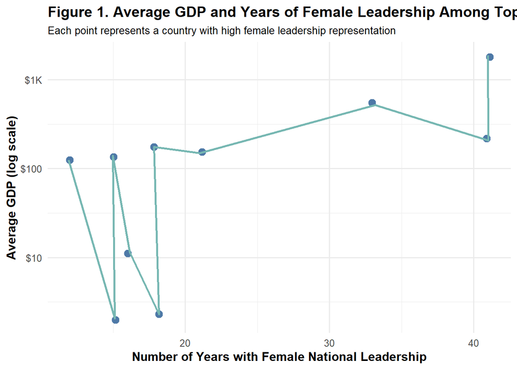

```r
ggplot(top_10_female_leaders_gdp,
       aes(x = years_with_female_leader, y = avg_gdp)) +
  geom_point(color = "#4E79A7",size = 3, position = position_jitter(width = 0.2, seed = 123)) +
  geom_line(color = "#76B7B2", linewidth = 1, position = position_jitter(width = 0.2, seed = 123)) +
  scale_y_log10(labels = scales::label_dollar(scale_cut = scales::cut_short_scale())) +
  labs(
    title = "Figure 1. Average GDP and Years of Female Leadership Among Top Countries",
    subtitle = "Each point represents a country with high female leadership representation",
    x = "Number of Years with Female National Leadership",
    y = "Average GDP (log scale)",
    alt = "Scatter plot with a connecting line showing the relationship between years of female leadership and average GDP for the top countries. GDP is displayed on a logarithmic scale."
  ) +
  theme_minimal(base_size = 12) +
  theme(
    plot.title = element_text(face = "bold"),
    plot.subtitle = element_text(size = 10),
    axis.title = element_text(face = "bold")
  )
```

Visually, we can see countries with similar years of female leadership display a wide range of GDP values, and there is no clear linear pattern between the two variables. Additionally, countries with the highest years of female leadership (around 40 years) span both moderate and high GDP values on the log scale.

We also wanted to visual the change in GDP. Similar to the data in Table 2, we created a lollipop graph to see the change in GDP for each of the countries with the highest number of female leaders over time. We compared GDP in the first and last observed years for each country using a log scale, with each line representing the change over time as well as a dark blue point representing the start year of data on a country, and a light blue representing the last year of data.

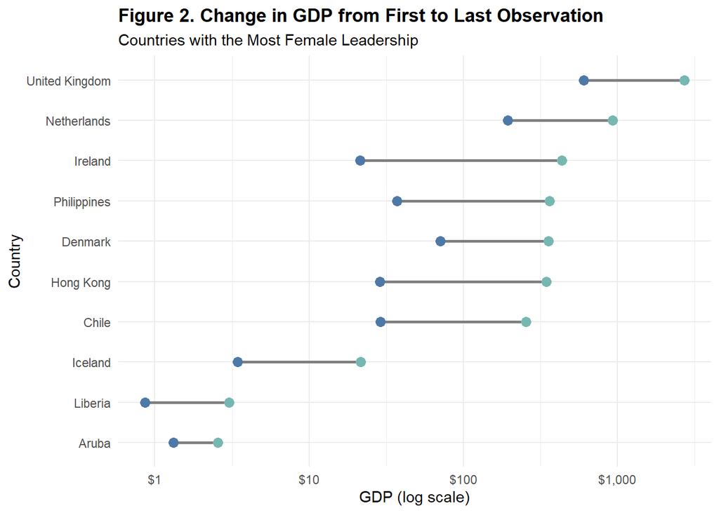

```r
ggplot(gdp_change_table,
       aes(y = reorder(country_name, last_gdp))) +
  geom_segment(
    aes(x = first_gdp, xend = last_gdp, yend = country_name), color = "gray50",linewidth = 1) +
  # starting GDP point
  geom_point(aes(x = first_gdp), color = "#4E79A7", size = 3) +
  # ending GDP point
  geom_point(aes(x = last_gdp), color = "#76B7B2", size = 3) +
  scale_x_log10(labels = label_dollar()) +
  labs(
    title = "Figure 2. Change in GDP from First to Last Observation",
    subtitle = "Countries with the Most Female Leadership",
    x = "GDP (log scale)",
    y = "Country",
    alt = "Popsicle plot comparing first and last GDP values for countries with the most female leadership. Each country has two points connected by a line showing change over time."
  ) +
  theme_minimal() +
  theme(
    plot.title = element_text(face = "bold")
  )
```

This plot shows that all countries show increases in GDP, though the distance between the starting and ending points varies, indicating different magnitudes of growth. Countries like the United Kingdom and the Netherlands start and end at higher GDP levels, while others such as Liberia and Aruba remain at much lower levels throughout the period.

### Data Model

```r
model_gdp_log <- lm(log(gdp) ~ female_leader, data = democracy_gdp)

#When trying to professionally format my output for the model, I did some research into broom package & linear model output

# https://broom.tidymodels.org/articles/broom.html & https://r-graph-gallery.com/366-regression-models-with-gtsummary.html

#below I used broom's tidy function for making tidy tibbles & broom's glance function to get additional terms from the output


# getting the coeefficients, t-statitics, p-value, standard deviation and rounding them
tidy_model <- tidy(model_gdp_log) |>
  mutate(term = recode(term,
      "(Intercept)" = "Intercept",
      "female_leaderTRUE" = "Female Leader"),
      estimate = round(estimate, 3),
      std.error = round(std.error, 3),
      statistic = round(statistic, 3),
      p.value = round(p.value, 3),
      section = "Coefficients")

# other results through glance
g <- glance(model_gdp_log)

#tibble of glanced values
model_stats <- tibble(
  section = "Model Fit",
  term = c("R-squared", "Adjusted R-squared", "F-statistic", "Model p-value", "Observations"),
  estimate = c(
    round(g$r.squared, 3),
    round(g$adj.r.squared, 3),
    round(g$statistic, 3),
    round(g$p.value, 3),
    g$nobs
  ), #setting NA values for this section of the output so its not misleading
  std.error = NA,
  statistic = NA,
  p.value = NA
)

# Combining both parts
table_data <- bind_rows(tidy_model, model_stats)

# Building gt table
gt_table <- table_data |>
  gt(rowname_col = "term",
    groupname_col = "section",
    caption = "Effect of Female Leadership on Logged GDP"
  ) |>
  tab_header( #Headers
    title = md("**Regression Results**"),
    subtitle = "Response variable: log(GDP)"
  ) |>
  cols_label( #labeling columns
    estimate = md("**Coefficient / Value**"),
    std.error = md("**Std. Error**"),
    statistic = md("**t-value**"),
    p.value = md("**p-value**")
  ) |>
  fmt_number( #rounding
    columns = c(estimate, std.error, statistic, p.value),
    decimals = 3
  ) |> #source note was in a lot of result examples i found so I added that as well
  tab_source_note(
    source_note = md("**Note:** Many countries did not have accessible data for female leadership or GDP for some years, or did not have complete data at all.")
  )

gt_table
```

Effect of Female Leadership on Logged GDP

**Regression Results**

Response variable: log(GDP)

|  | **Coefficient / Value** | **Std. Error** | **t-value** | **p-value** |
| --- | --- | --- | --- | --- |
| Coefficients |  |  |  |  |
| Intercept | 2.466 | 2.270 | 1.086 | 0.278 |
| Female Leader | 1.853 | 2.273 | 0.815 | 0.416 |
| Model Fit |  |  |  |  |
| R-squared | 0.002 | NA | NA | NA |
| Adjusted R-squared | −0.001 | NA | NA | NA |
| F-statistic | 0.664 | NA | NA | NA |
| Model p-value | 0.416 | NA | NA | NA |
| Observations | 380.000 | NA | NA | NA |

**Note:** Many countries did not have accessible data for female leadership or GDP for some years, or did not have complete data at all.

The results of the linear regression model on the relationship between female leadership and GDP show that there is no statistically significant association between the two variables. We decided to use GDP logged to reduce skewness that we saw in our original analysis through plotting. The model produced an F-statistic of 0.664 with a p-value of 0.416. Because this p-value is greater than 0.05, we fail to reject the null hypothesis and conclude that there is no evidence that countries with many years of female leaders have different GDP levels compared to those without many years of female leaders.

Although the estimated coefficient for female leadership is positive, and 5.38 for normal log which suggests higher GDP in countries with female leaders by over 500%, this result is not statistically significant and should be interpreted with caution. The large standard error & R squared indicates that the estimate varies greatly, and the model itself explains very little of the variation in GDP (R² = 0.002). This means that female leadership alone is not a meaningful predictor of economic GDP in this analysis. Additionally, a substantial number of observations were dropped due to missing data in both gender leadership and GDP, which may further limit the reliability and generalizability of these results.

### Conclusion: What We Found

Overall, the analysis of the top countries with the most years of female national leadership shows that GDP increased over time for all of these countries, although the magnitude of growth varied widely. The tables and visualizations for these top countries indicate that similar lengths of female leadership are associated with very different GDP levels and growth patterns, suggesting no clear relationship within this subset. When expanding the analysis to all countries using the regression model, there is also no statistically significant association between female leadership and logged GDP, and the model explains very little of the variation in GDP. These results suggest that while GDP has generally increased over time, there is no consistent evidence from either the top-country analysis or the all countries with available gdp observations that female leadership alone is a strong predictor of economic outcomes.

## Does the type of regime of a country/region affect the unemployment rate?

When exploring the relationship between regime of a country and unemployment rate, we first wanted to summarize the data of number of countries in each regime, average unemployment, number of countries per regime with more than 10% unemployment. Using those data, we were then about to find out what percent of countries per regime had an unemployment rate about 10%. We filtered our data of country unemployment & regime to observations in 2019 to keep things constant per country and regime.

```r
regime_summary_table <- democracy_unemp |>
  filter(year == 2019) |>
  distinct(country_name, regime_category, .keep_all = TRUE) |>
  group_by(regime_category) |>
  summarize(
    number_of_countries = n_distinct(country_name),
    avg_unemployment = mean(unemployment_rate, na.rm = TRUE),
    above_10_percent = sum(unemployment_rate > 10, na.rm = TRUE),
    percent_above_10 = above_10_percent / number_of_countries,
    .groups = "drop"
  ) |>
  arrange(desc(percent_above_10))

regime_summary_table |>
  gt(caption = "Table 3. Countries with High Unemployment by Political Regime Type in 2019") |>
  tab_header(
    title = md("**High Unemployment by Political Regime Type**"),
    subtitle = "Share of countries with unemployment rates above 10% in 2019"
  ) |>
  cols_label(
    regime_category = "Regime Type",
    number_of_countries = "Number of Countries",
    avg_unemployment = "Average Unemployment (%)",
    above_10_percent = "Countries Above 10%",
    percent_above_10 = "Percent Above 10%"
  ) |>
  fmt_number(avg_unemployment, decimals = 2) |>
  fmt_percent(percent_above_10, decimals = 1) |>
  tab_style(
    style = cell_text(weight = "bold"),
    locations = cells_column_labels()
  ) |>
  tab_style(
    style = cell_fill(color = "#76B7B2"),
    locations = cells_body(columns = percent_above_10)
  )
```

Table 3. Countries with High Unemployment by Political Regime Type in 2019

**High Unemployment by Political Regime Type**

Share of countries with unemployment rates above 10% in 2019

| Regime Type | Number of Countries | Average Unemployment (%) | Countries Above 10% | Percent Above 10% |
| --- | --- | --- | --- | --- |
| Civilian dictatorship | 15 | 8.55 | 5 | 33.3% |
| Military dictatorship | 4 | 9.05 | 1 | 25.0% |
| Royal dictatorship | 5 | 9.08 | 1 | 20.0% |
| Mixed democratic | 21 | 8.00 | 4 | 19.0% |
| Parliamentary democracy | 30 | 6.34 | 5 | 16.7% |
| Presidential democracy | 24 | 6.88 | 4 | 16.7% |
| Constituent Country of the Netherlands | 1 | 5.20 | 0 | 0.0% |
| Special Administrative Region of China | 2 | 2.30 | 0 | 0.0% |
| Unincorporated territory of the United States with Commonwealth status | 1 | 8.30 | 0 | 0.0% |

In our table, we found that unemployment rates across a wide range of political regime types in 2019, including both averages and the share of countries with unemployment above 10%. There is substantial variation across regimes, with some categories showing higher average unemployment and larger proportions of countries above the 10% mark, while others have lower averages and few or no countries exceeding that level. Overall, the data highlights that unemployment levels and the prevalence of high unemployment differ considerably across political regime types.

Next, we wanted to investigate change of average unemployment by Regime. We created a table to display the first and last year of data available for each regime, the aaverage unemployment percentage for the first and last years, and then calculated the change in average unemployment per regime.

```r
summarize_regime_trend <- function(regime_name) {
  one_regime <- democracy_unemp |>
    filter(
      regime_category == regime_name,
      !is.na(unemployment_rate)
    ) |>
    group_by(year) |>
    summarize(
      avg_unemployment = mean(unemployment_rate, na.rm = TRUE),
      .groups = "drop"
    ) |>
    arrange(year)


  one_regime |>
    summarize(
      regime_category = regime_name,
      first_year = first(year),
      last_year = last(year),
      first_avg_unemployment = first(avg_unemployment),
      last_avg_unemployment = last(avg_unemployment),
      change_in_unemployment = last_avg_unemployment - first_avg_unemployment)
}

regime_trend_table <- democracy_unemp |>
  distinct(regime_category) |>
  drop_na(regime_category) |>
  pull(regime_category) |>
  map_dfr(summarize_regime_trend)

regime_trend_table |>
  gt(caption = "Table 4. Change in Average Unemployment Over Time by Political Regime Type") |>
  tab_header(
    title = md("**Change in Average Unemployment by Regime Type**"),
    subtitle = "First and last available average unemployment rates across all years"
  ) |>
  cols_label(
    regime_category = "Regime Type",
    first_year = "First Year",
    last_year = "Last Year",
    first_avg_unemployment = "Average Unemployment in First Year (%)",
    last_avg_unemployment = "Average Unemployment in Last Year (%)",
    change_in_unemployment = "Change in Average Unemployment (%)"
  ) |>
  fmt_number(
    columns = c(first_avg_unemployment, last_avg_unemployment, change_in_unemployment),
    decimals = 2
  ) |>
  tab_style(
    style = cell_text(weight = "bold"),
    locations = cells_column_labels()
  ) |>
  tab_style(
    style = cell_fill(color = "#76B7B2"),
    locations = cells_body(columns = change_in_unemployment)
  )
```

Table 4. Change in Average Unemployment Over Time by Political Regime Type

**Change in Average Unemployment by Regime Type**

First and last available average unemployment rates across all years

| Regime Type | First Year | Last Year | Average Unemployment in First Year (%) | Average Unemployment in Last Year (%) | Change in Average Unemployment (%) |
| --- | --- | --- | --- | --- | --- |
| Military dictatorship | 1980 | 2020 | 7.97 | 12.55 | 4.58 |
| Civilian dictatorship | 1980 | 2020 | 8.31 | 8.88 | 0.56 |
| Parliamentary democracy | 1980 | 2020 | 6.61 | 8.20 | 1.59 |
| Presidential democracy | 1980 | 2020 | 5.20 | 9.60 | 4.40 |
| Mixed democratic | 1980 | 2020 | 4.46 | 8.45 | 4.00 |
| Constituent Country of the Netherlands | 1991 | 2020 | 6.10 | 8.60 | 2.50 |
| Royal dictatorship | 1984 | 2020 | 5.40 | 11.10 | 5.70 |
| Crown Colony | 1980 | 1980 | 3.80 | 3.80 | 0.00 |
| British Dependent Territory | 1981 | 1997 | 3.90 | 2.20 | −1.70 |
| Special Administrative Region of China | 1998 | 2020 | 4.70 | 4.20 | −0.50 |
| Unincorporated territory of the United States with Commonwealth status | 1980 | 2020 | 17.10 | 8.80 | −8.30 |

These summaries showed that most regime types experienced increases in average unemployment, though the size of these increases varies, with some categories such as royal dictatorship and military dictatorship showing larger changes. A few regime types show little to no change or even decreases over time, indicating that trends in unemployment are not consistent across all political systems.

After exploring the data numerically, w e wanted to visualize the unemployment rates more clearly. We started with a boxplot graph of the unemployment rates per regime category in 2019, similar to the data in table 3. From this, we were able to more see spread and outliers more visually.

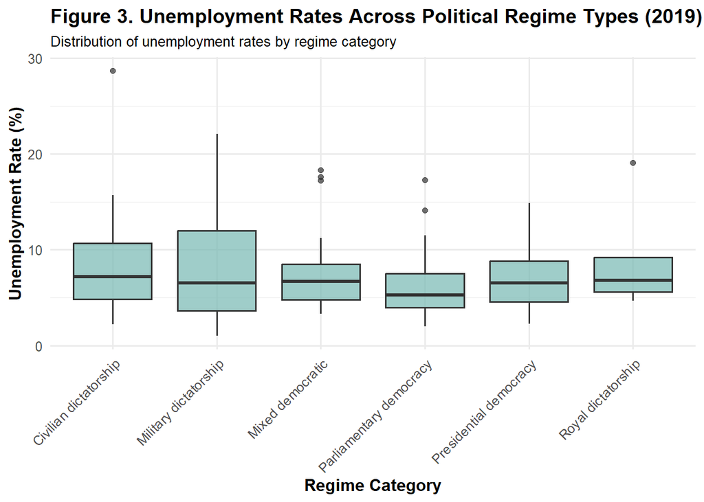

```r
unemploy_data <- democracy_unemp |>
  inner_join(gdp_df, by = c("country_code", "year"), relationship = "many-to-many") |>
  filter(year == 2019,
         !is.na(regime_category_index))

ggplot(unemploy_data,
       aes(x = regime_category, y = unemployment_rate)) +
  geom_boxplot(fill = "#76B7B2",alpha = 0.7) +
  labs(
    title = "Figure 3. Unemployment Rates Across Political Regime Types (2019)",
    subtitle = "Distribution of unemployment rates by regime category",
    x = "Regime Category",
    y = "Unemployment Rate (%)",
    alt = "Boxplot comparing unemployment rates across political regime types in 2019. Each box shows the distribution, including median and spread, of unemployment rates within each regime category."
  ) +
  theme_minimal(base_size = 12) +
  theme(
    plot.title = element_text(face = "bold"),
    plot.subtitle = element_text(size = 10),
    axis.title = element_text(face = "bold"),
    axis.text.x = element_text(angle = 45, hjust = 1)
  )
```

Using medians, spread, and outliers, we were able to display that most regime categories have overlapping ranges, though some, such as military and civil dictatorships, display wider variability and higher upper values. Parliamentary and presidential democracies tend to have slightly lower median unemployment rates and less spread compared to several non-democratic regime types. The use of boxplots let us see the trends outside of average numeric values.

In table 4, we showed changes in average unemployment by regime. We saw a very high change in average unemployment for Royal Dictatorships with 5.70 percent increase, which was the highest unemployment increase. But in the previous boxplot graph, the spread showed a pretty similar spread to the other regimes other than the one outlier for 2019 unemployment data. With this information, we wanted to investigate Royal Dictatorships more. We decided to investigate Royal Dictatorship country’s unemployment with a line & ribbon plot.

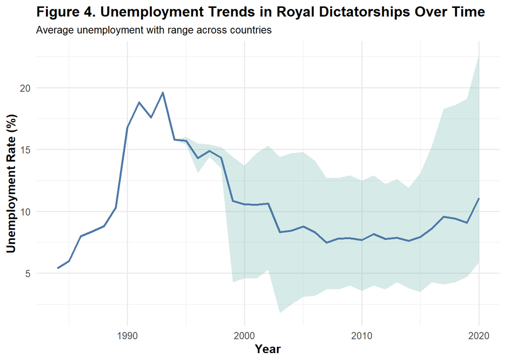

```r
one_regime_data <- democracy_unemp |>
  filter(
    regime_category == "Royal dictatorship",
    !is.na(unemployment_rate)
  ) |>
  group_by(year) |>
  summarize(
    avg_unemployment = mean(unemployment_rate, na.rm = TRUE),
    min_unemployment = min(unemployment_rate, na.rm = TRUE),
    max_unemployment = max(unemployment_rate, na.rm = TRUE),
    .groups = "drop"
  )

ggplot(one_regime_data,
       aes(x = year, y = avg_unemployment)) +
  geom_ribbon(aes(ymin = min_unemployment, ymax = max_unemployment),fill = "#76B7B2",alpha = 0.3) +
  geom_line(color = "#4E79A7", linewidth = 1) +
  labs(
    title =  "Figure 4. Unemployment Trends in Royal Dictatorships Over Time",
    subtitle = "Average unemployment with range across countries",
    x = "Year",
    y = "Unemployment Rate (%)",
    alt = "Line and ribbon plot showing unemployment trends over time within royal dictatorships. The line represents average unemployment, and the shaded ribbon shows the range across countries."
  ) +
  theme_minimal(base_size = 12) +
  theme(
    plot.title = element_text(face = "bold"),
    plot.subtitle = element_text(size = 10),
    axis.title = element_text(face = "bold")
  )
```

The line shows that average unemployment rose sharply in the early 1990s, declined in the 2000s, and then gradually increased again toward 2020. The shaded ribbon indicates that the range of unemployment across countries widens over time, suggesting increasing variability within this regime type. It seems that Royal Dictatorships had more variety in unemployment after the 1990s.

### Conclusion: What We Found

Overall, the analysis shows that unemployment rates vary across political regime types, but the differences are not uniform or consistent across all measures. The summary table indicates that some regime types have higher average unemployment and a larger share of countries with high unemployment, while others tend to have lower levels. Over time, most regime types experienced increases in average unemployment, although the amount of change differs, with some regimes showing larger increases and others remaining relatively stable or even decreasing. The boxplot further shows substantial overlap in unemployment distributions across regimes, suggesting that no single regime type consistently has distinctly higher or lower unemployment. A closer look at royal dictatorships highlights that unemployment trends can fluctuate over time and vary widely across countries within the same regime. Overall, these results suggest that while unemployment differs by political regime type, there is no clear or consistent pattern indicating that one type of regime systematically leads to higher or lower unemployment outcomes.